Every Friday, FiveThirtyEight.com posts a weekly Riddler challenge. On February 10th, 2017, the following Riddler Express was posted:

> *You’re a lifeguard standing on the beach, right at the edge of the water, and gazing out over the ocean. You see someone drowning 100 meters to the right of you and 100 meters away from shore. You can run 100 meters in 15 seconds and swim 100 meters in 75 seconds. (The beach drops off steeply, meaning that you can’t run in the water.) What’s the fastest you can get to the victim?*

So, you have to make a choice. For how long on the beach do you run before you decide to turn and begin swimming? There is clearly a trade-off to make here, since the shortest distance (swimming without running) might actually take longer than running for a bit, and then deciding to swim.

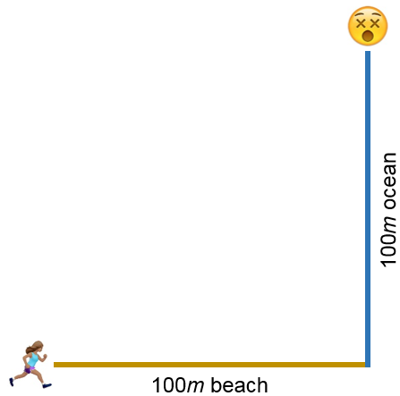

This first struck me as a possible creative use of [Snell’s Law](https://en.wikipedia.org/wiki/Snell's_law), which would allow us to decide at what angle to turn, and hence at what distance down the beach to turn. I then realized that this is probably more simply framed as a geometry problem. And who doesn’t love a good geometry problem?!

Consider the following strategy: You run a distance of $d_1$ meters on the beach. You then turn, and swim directly towards the drowning swimmer. We’ll call the swimming distance $d_2$.

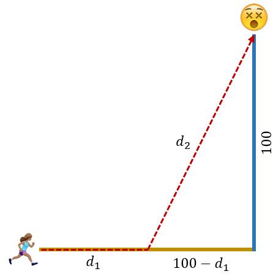

How fast can you run $d_1$? Well, we know we can run 100 meters in 15 seconds. Let’s call $t_1$ the amount of time it takes to run $d_1$:

$$t_1 = d_1 \times \frac{15}{100}$$

We can then use the Pythagorean Theorem to find $t_2$, the time it takes to run $d_2$:

$$\begin{align}
t_2 &= d_2 \times \frac{75}{100} \\
&= \sqrt{100^2 + (100 - d_1)^2} \times \frac{75}{100}
\end{align}$$

We want to minimize the total time, i.e., minimize $t_1 + t_2$:

$$\min \{t_1 + t_2\} = \min\left\{0.15d_1 + 0.75\sqrt{100^2 + (100 - d_1)^2}\right\}$$
To solve this, we could *probably* use calculus, but… yuck. Let’s let R do the work for us:

```r
f <- function(d) 0.15 * d + 0.75 * sqrt(100^2 + (100 - d)^2)
optimize(f, interval = c(0, 100))
```

```
## $minimum
## [1] 79.58758
##
## $objective
## [1] 88.48469
```

And that’s it! The optimal choice is to start swimming after running 79.59m. Even still, it would take us 88.48 seconds to get to the drowning swimmer. Hope you know CPR.